# Differential Expression Analysis - FUBP1 KD

Differential Expression Analysis of FUBP1 KD and WT cell lines

Martin Brand

Dezember 25, 2022

# Scientific Background

Scientific background of this analysis is the research into the FUBP1 (Far Upstream Element Binding Protein 1). FUBP1 has been identified as a DNA-binding protein by Duncan et al. (1994). In recent years, studies have shown that FUBP1 is also an RNA-binding protein that plays an important role in alternative splicing by Debaize and Troadec (2019). However, the exact function of FUBP1 is not yet known. In this project, I want to explore the genetic dependencies of FUBP1. The aim of this analysis was to find out whether knock-down (KD) of the FUBP1 gene leads to a change in gene expression of the U2-related genes published by Wahl, Will, and Lührmann (2009).

```r
library(DESeq2)
library(pheatmap)
library(RColorBrewer)
library(apeglm)
library(ggplot2)
library(ggrastr)
library(dplyr)
library(ggrepel)
library(reshape2)
```

# Data Preprocessing

I loaded the read counts tables which output from featureCounts and created an experiment design table with two wild type (WT) cell lines and two cell lines with FUBP1 KD.

```r
dir <- "C:/Users/Martin/Documents/Master/Forschungspraktikum/differential_expression_analysis/project/data/"
files = list.files(paste0(dir,"feature_counts_output"))

sampleFiles <- files
sampleCondition <- factor(rep(c("Ctrl", "KD"), each=2))
sampleReplicate <- factor(paste("Rep", 1:2, sep = "_",2))

sampleTable <- data.frame(sampleName = sampleFiles,
                          fileName = sampleFiles,
                          condition = sampleCondition,
                          replicate = sampleReplicate)
sampleTable
```

```
##        sampleName        fileName condition replicate
## 1 ENCFF059NNE.txt ENCFF059NNE.txt      Ctrl   Rep_1_2
## 2 ENCFF607DWM.txt ENCFF607DWM.txt      Ctrl   Rep_2_2
## 3 ENCFF643CGB.txt ENCFF643CGB.txt        KD   Rep_1_2
## 4 ENCFF767VAA.txt ENCFF767VAA.txt        KD   Rep_2_2
```

I put the data into the specific format that is required for the DESeq analysis and performed the analysis. The result from the DESeq analysis contains the number of read counts for genes for each sample.

```r
# fit format
count_table <- read.table(paste0(dir, "feature_counts_output/", files[1]), header = T)
count_table <- count_table[, c(1,ncol(count_table))]

for (i in 2:4) {
  tmp <- read.table(paste0(dir, "feature_counts_output/", files[i]), header = T)
  tmp <- tmp[, c(1,ncol(tmp))]
  count_table <- merge(count_table, tmp, by = "Geneid")
}

colnames(count_table)[2:5] <- c("WT1", "WT2", "KD1", "KD2")

# problem: doubled genes => delete all entries with zero counts
count_table <- count_table[rowSums(count_table[,2:5]) != 0,]

# delete version number of gene IDs
count_table$Geneid <- substr(count_table$Geneid, 1, 15)

# move gene IDs from column to row names
rownames(count_table) <- count_table$Geneid
count_table$Geneid <- NULL

# analysis
dds <- DESeqDataSetFromMatrix(countData = count_table,
                              colData = sampleTable,
                              design = ~ condition)

dds <- DESeq(dds)

head(counts(dds))
```

```
##                  WT1  WT2 KD1  KD2
## ENSG00000000003    2    0   1    5
## ENSG00000000005    1    0   1    0
## ENSG00000000419 1674 1391 622 1354
## ENSG00000000457  265  217 156  368
## ENSG00000000460 1205 1083 474 1207
## ENSG00000000938    0    0   0    4
```

# Quality Control

For quality control, I calculated the differences between the samples using the regulized log transformation and visualized the results in a heatmap. As the heatmap shows, the differences between WT and FUBP1 KD cell lines are larger than the differences between replicates.

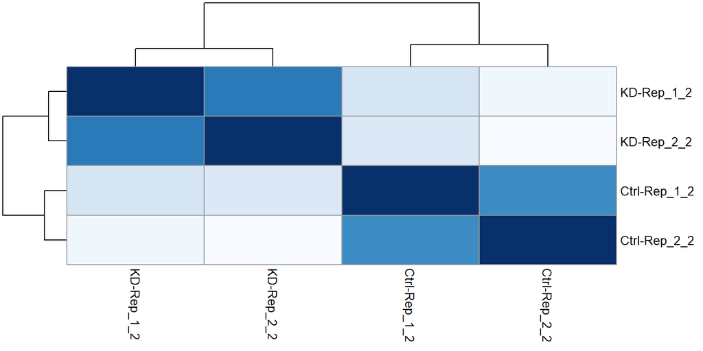

```r
rld <- rlog(dds, blind = FALSE)
sampleDists <- dist(t(assay(rld)))
sampleDistMatrix <- as.matrix(sampleDists)
rownames(sampleDistMatrix) <- paste(rld$condition, rld$replicate, sep = "-")
colnames(sampleDistMatrix) <- rownames(sampleDistMatrix)
colors <- colorRampPalette(rev(brewer.pal(9, "Blues")))(255)

pheatmap(sampleDistMatrix, clustering_distance_rows = sampleDists,
         clustering_distance_cols = sampleDists, col=colors, legend = FALSE)
```

The second quality check is done with a Principal Component Analysis (PCA). The FUBP1 KD and WT cell lines show a significant difference in Principal Component 1 (PC1), which accounts for 97.7% of the variance in the data.

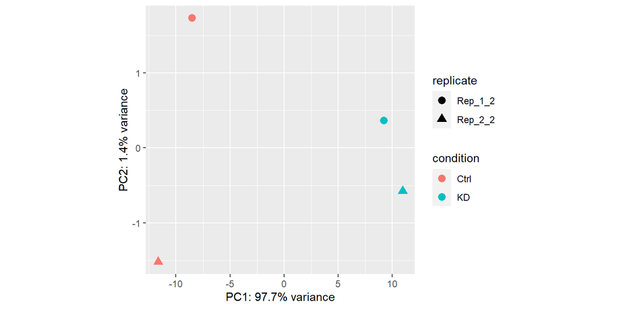

```r
pcaData <- plotPCA(rld, intgroup=c("condition", "replicate"), returnData=TRUE)
percentVar <- round(100 * attr(pcaData,"percentVar"), digits=1)
ggplot(pcaData, aes(x=PC1, y=PC2, color=condition, shape=replicate)) +
  geom_point(size=3) +
  xlab(paste0("PC1: ", percentVar[1], "% variance")) +
  ylab(paste0("PC2: ", percentVar[2], "% variance")) +
  coord_fixed() +
  theme(aspect.ratio = 1)
```

Considering both quality checks, we can say that the data quality is very good as we can see the expected patterns. Gene expression for FUBP1 KD and WT cell lines differs more than for replicates.